# Patterns of Rides in Ford GoBike System

## Investigation Overview

In this investigation, I wanted to look at the Patterns that users usually take and the Most insightfull user characteristics

## Dataset Overview

The data consists of information regarding approximately 183,000 rides made in a bike-sharing system covering the greater San Francisco Bay area. The data Features Details about the ride from their start, End Locations to their durations, Start & end time, User Details

## Distribution of Ride During the day

### How can We Benefit From this ?

Adding more bike stations near workplaces, downtown, universities, or places with alot of stores

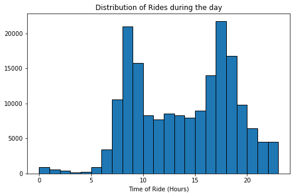

## Distribution of Ride During the Week

From the previous Visual and the current visual we can be sure of the work cycle pattern of the rides as most rides are during the weekday then drop during the weekend

### How can We Benefit From this ?

We can add more stations near parks or entartainment places where users usually go during the weekend to increase the number of rides during it

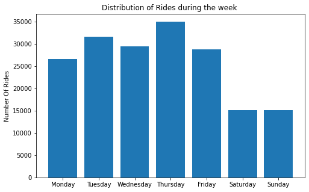

## Users day Balance (Morning)

The Day is mostly skewed toward work cycle as the age decreases and gets more normally distributed as the age increase which can be explained by the activites of certain age group for example users in their 20s-40s have various places which they normally attend like Universities, Work while older aged users would probably be retired so their day is more distibuted

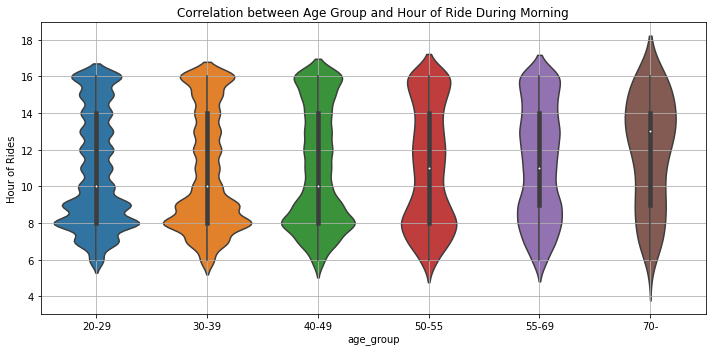

## Users day Balance (Evening)

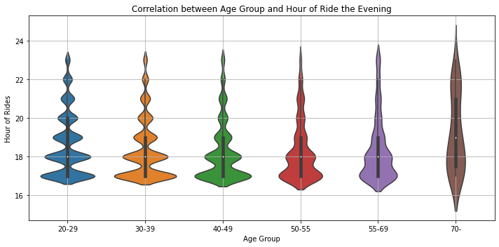

## Ride Duration Distribution (minutes)

We can see that most Rides lie between 5-25 minutes which indicate a close distance trip but are these trips normally around the same areas or are they mostly in the surrounding or other areas,we will see this in the next Visual

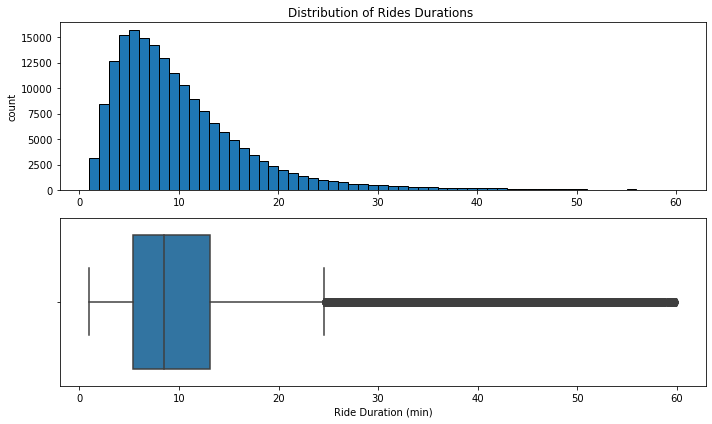

## Where do users normally go to?

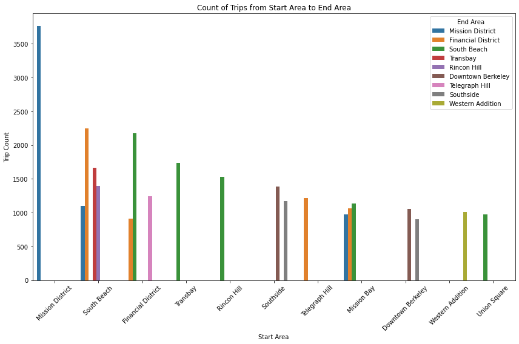

## Distribution of Rides in highest ride denisty areas during the week

We can see that count varies each day and significantly drops everywhere during the end of the week but we can notice the count of rides during the weekend doesn't significantly decrease as the total ride count decrease we can look more on that by seeing the areas in the middle of the rankings

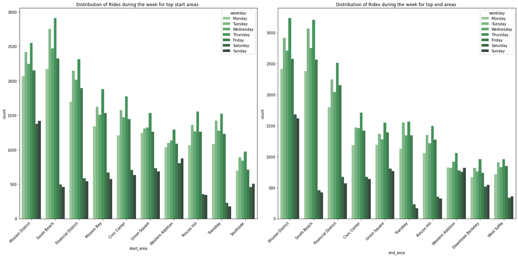

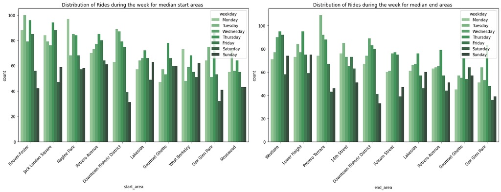

## Our Users by gender

We can see that most of the users are men and by a significant number which isn't a good indication considering women are 50% of the workforce and can be a great increase if we directed some advertisments or helped to view comfort in usage of bike in your everyday activity

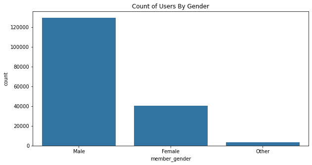

## The Type of the Software User

The Type of our Users are moslty Subscribed but if we wanted to increase the number of Users considering amount of customers is nearly 10% and they use the bike more on average we can make the bike a higher fare for customers but give them the first ride for free or for a discount if they subscibed which most propably would work on most customers

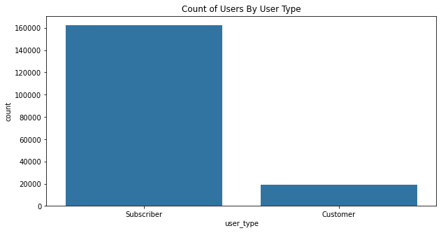

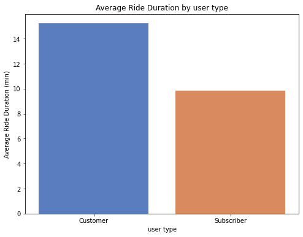